# backpack

```r
library(tidyverse)
library(CodeClanData)
```

```r
backpack
```

| backpack_weight | body_weight | ratio | back_problems | major | year | sex | status | units |
| --- | --- | --- | --- | --- | --- | --- | --- | --- |
| 9 | 125 | 0.0720000 | 1 | Bio | 3 | Female | U | 13 |
| 8 | 195 | 0.0410256 | 0 | Philosophy | 5 | Male | U | 12 |
| 10 | 120 | 0.0833333 | 1 | GRC | 4 | Female | U | 14 |
| 6 | 155 | 0.0387097 | 0 | CSC | 6 | Male | G | 0 |
| 8 | 180 | 0.0444444 | 0 | EE | 2 | Female | U | 14 |
| 5 | 240 | 0.0208333 | 0 | History | 0 | Male | G | 0 |
| 8 | 170 | 0.0470588 | 0 | CM | 3 | Male | U | 15 |
| 4 | 185 | 0.0216216 | 1 | ARCE | 5 | Female | U | 18 |
| 5 | 130 | 0.0384615 | 0 | Bio | 4 | Female | U | 14 |
| 2 | 120 | 0.0166667 | 0 | Bio | 5 | Female | U | 8 |

[output cut: 90 more lines]

- Question 1.

Load in the libraries you need, and look at the backpack data. Take note of variable names and dimensions.

```r
dim(backpack)
```

```
[1] 100   9
```

```r
colnames(backpack)
```

```
[1] "backpack_weight" "body_weight"     "ratio"           "back_problems"   "major"
[6] "year"            "sex"             "status"          "units"
```

- Question 2.

What is the distribution of backpack weights that students are carrying? Choose an appropriate graph to show the distribution.

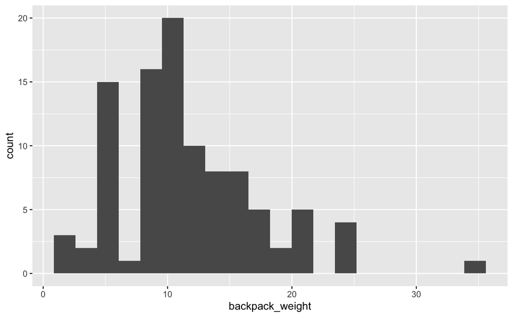

```r
ggplot(backpack) +
  aes(x = backpack_weight) +
  geom_histogram(bins = 20)
```

- Question 3.

Are there differences in backpack weight between sex?

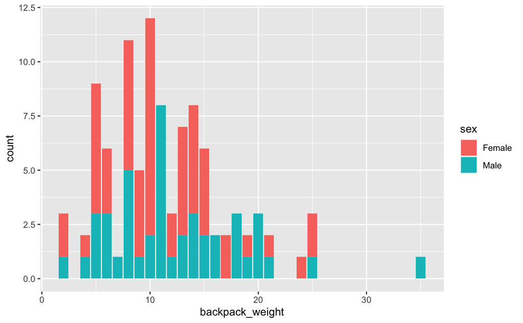

```r
ggplot(backpack) +
  aes(x = backpack_weight, fill = sex) +
  geom_bar()
```

Answer: from this graph there isnt much difference in the backpack weight between the sex.

- Question 4.

What is the relationship between body weight and backpack weight?

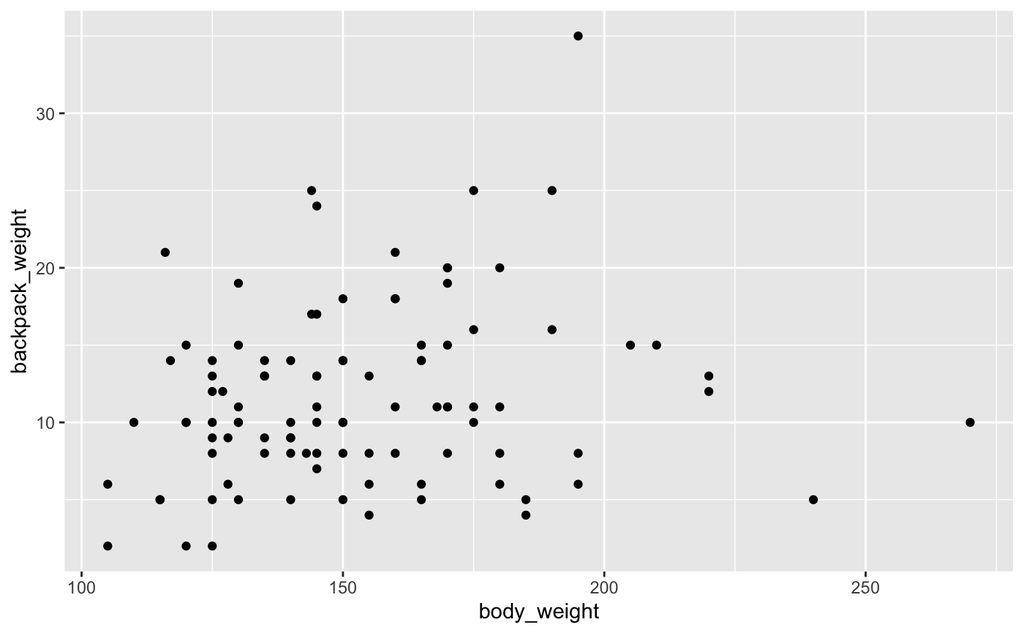

```r
ggplot(backpack) +
  aes(x = body_weight, y = backpack_weight) +
  geom_point()
```

Answer: generally the heavier the body_weight the heavier the backpack_weight

- Question 5.

Is this relationship different between men and women? Choose an appropriate plot and interpret your findings.

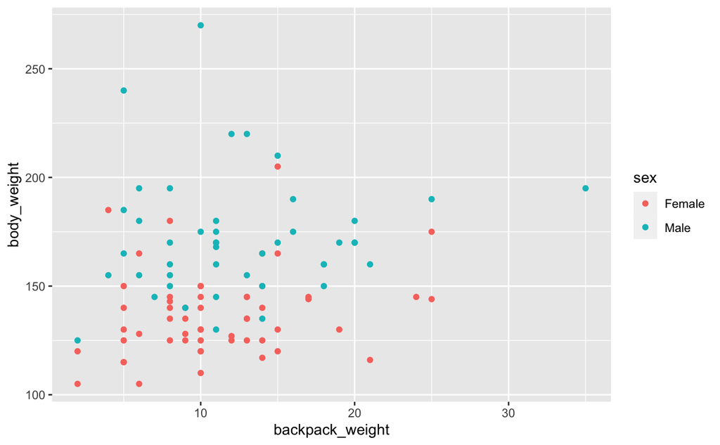

```r
ggplot(backpack) +
  aes(x = backpack_weight, y = body_weight, colour = sex) +
  geom_point()
```

Answer: Males generally weight more but backpack_weight is fairly even.

- Question 6.

What proportion of students report back pain?

```r
ggplot(backpack) +
  aes(x = back_problems) +
  geom_bar(position = 'dodge', stat='identity') +
  geom_text(position = position_dodge(width=0.9), vjust=-0.25)
```

[output not shown]

```
Error: geom_bar requires the following missing aesthetics: y
Run `rlang::last_error()` to see where the error occurred.
```

Answer: around 1/3 of students reported back problems.

- Question 7.

Is this proportion different between men and women?

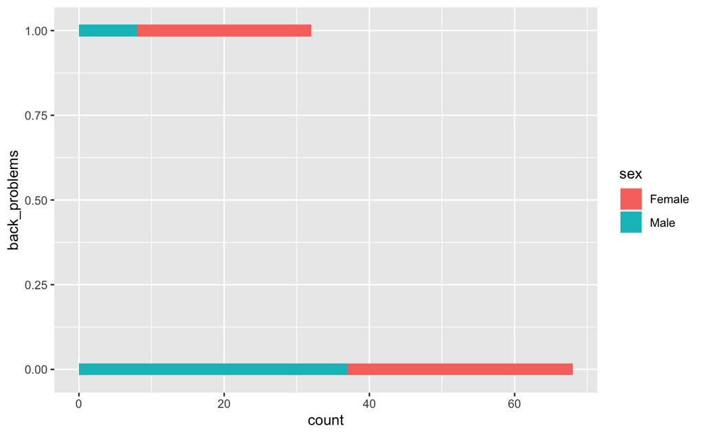

```r
ggplot(backpack) +
  aes(x = back_problems, fill = sex) +
  geom_histogram() +
  coord_flip()
```

Answer: A far higher % of Females reported to have vack problems, almost 1/2. Whereas Males were only around 1/4.5.

- Question 8.

Now you’ve investigated your data separately, create plots to describe the relationship between backpack weight, body weight, gender and reported backpain.

Try both backpack_weight and body_weight as well as the ratio.

Hint: faceting would be useful here

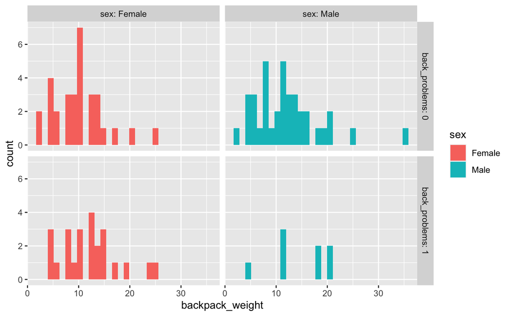

```r
ggplot(backpack) +
  aes(x = backpack_weight, fill = sex) +
  geom_histogram() +
  facet_grid(back_problems ~ sex, labeller =
               "label_both")
```

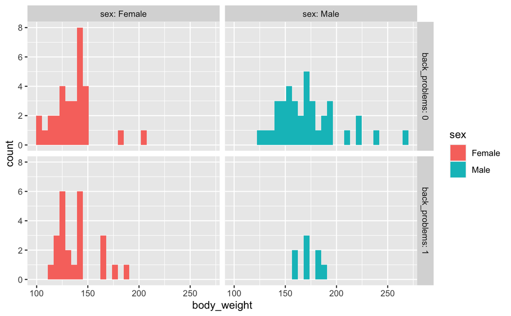

```r
ggplot(backpack) +
  aes(x = body_weight, fill = sex) +
  geom_histogram() +
  facet_grid(back_problems ~ sex, labeller =
               "label_both")
```